# Consumo de Combustíveis — Relatório

Alef Ryan

06/09/2025

# 1 Pacotes

```r
library(tidyverse)
library(seasonal)
library(geobr)
library(sf)
library(sidrar)
library(gganimate)
library(purrr)
```

# 2 Puxando dados

```r
arq <- here::here("dados", "vendas_distribuidoras_anp 1 (2).xlsx")

# Checagem defensiva (opcional, mas útil)
stopifnot(file.exists(arq))

diesel   <- readxl::read_excel(arq, sheet = "diesel")
gasolina <- readxl::read_excel(arq, sheet = "gasolina")
etanol   <- readxl::read_excel(arq, sheet = "etanol")
```

## 2.1 Organização da base

```r
diesel$tipo   <- "diesel"
gasolina$tipo <- "gasolina"
etanol$tipo   <- "etanol"

dados <- rbind(diesel, gasolina, etanol)

dados <- dados |>
  pivot_longer(
    cols      = starts_with("20"),
    names_to  = "ano",
    values_to = "Volume"
  ) |>
  rename(
    uf_sigla = regiao,
    Ano      = ano
  ) |>
  mutate(uf_sigla = toupper(uf_sigla))
```

# 3 Série Temporal

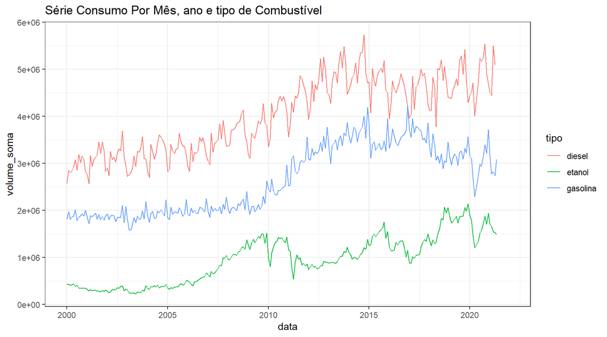

```r
dados |>
  filter(uf_sigla == "BR") |>
  mutate(
    mes  = as.character(meses),
    data = my(paste(mes, Ano))
  ) |>
  group_by(tipo, data) |>
  summarise(volume_soma = sum(Volume)) |>
  ggplot(aes(x = data, y = volume_soma, color = tipo)) +
  geom_line() +
  labs(title = "Série Consumo Por Mês, ano e tipo de Combustível") +
  theme_bw()
```

## 3.1 Separando séries

```r
series <- dados |>
  mutate(
    mes  = as.character(meses),
    data = my(paste(mes, Ano))
  ) |>
  group_by(tipo, data) |>
  summarise(volume_soma = sum(Volume))
```

## 3.2 Sazonalidade

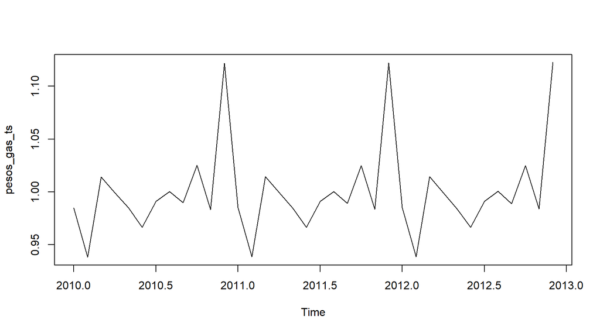

```r
# Gasolina
gasolina_ts <- series |>
  select(volume_soma, tipo, data) |>
  filter(tipo == "gasolina")
gasolina_ts <- ts(gasolina_ts$volume_soma, frequency = 12, start = c(2000, 01))
ajuste_gas  <- seas(gasolina_ts)
pesos_gas_ts <- series(ajuste_gas, "s10")
pesos_gas_ts <- window(pesos_gas_ts, start = c(2010, 1), end = c(2012, 12))
plot(pesos_gas_ts)
```

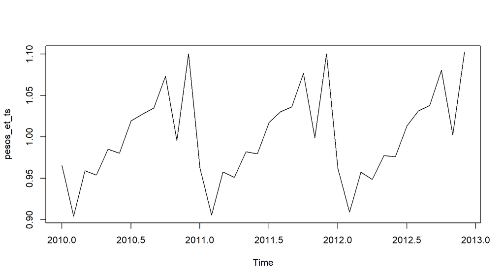

```r
# Etanol
etanol_ts <- series |>
  select(volume_soma, tipo, data) |>
  filter(tipo == "etanol")
etanol_ts <- ts(etanol_ts$volume_soma, frequency = 12, start = c(2000, 01))
ajuste_et  <- seas(etanol_ts)
pesos_et_ts <- series(ajuste_et, "s10")
pesos_et_ts <- window(pesos_et_ts, start = c(2010, 1), end = c(2012, 12))
plot(pesos_et_ts)
```

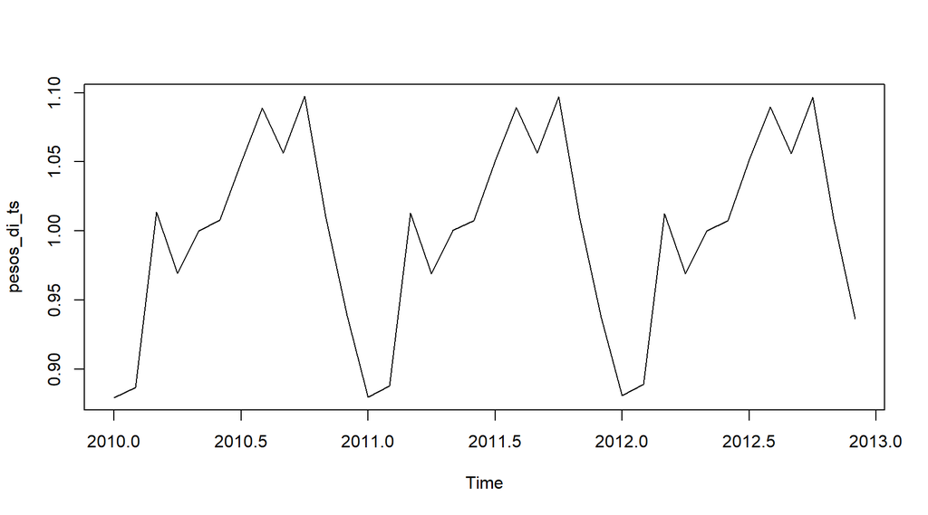

```r
# Diesel
diesel_ts <- series |>
  select(volume_soma, tipo, data) |>
  filter(tipo == "diesel")
disel_ts <- ts(diesel_ts$volume_soma, frequency = 12, start = c(2000, 01))
ajuste_di  <- seas(disel_ts)
pesos_di_ts <- series(ajuste_di, "s10")
pesos_di_ts <- window(pesos_di_ts, start = c(2010, 1), end = c(2012, 12))
plot(pesos_di_ts)
```

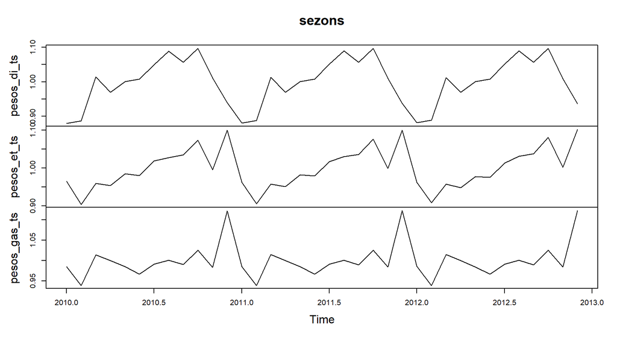

```r
# Conjunto
sezons <- cbind(pesos_di_ts, pesos_et_ts, pesos_gas_ts)
plot(sezons)
```

As vendas apresentam um padrão sazonal claro. Para a gasolina, no final do ano as vendas são mais fortes e, no início do ano, mais fracas. Já o etanol cresce de forma constante ao longo do ano, mas apresenta uma queda abrupta perto do fim do período. O diesel segue padrão semelhante ao do etanol: as vendas aumentam no decorrer do ano e caem repentinamente no final.